# Compito di Statistica

Scrivere in stampatello

| COGNOME | $\LARGE\square$ | $\LARGE\square$ | $\LARGE\square$ | $\LARGE\square$ | $\LARGE\square$ | $\LARGE\square$ | $\LARGE\square$ | $\LARGE\square$ | $\LARGE\square$ | $\LARGE\square$ | $\LARGE\square$ | $\LARGE\square$ | $\LARGE\square$ | $\LARGE\square$ | $\LARGE\square$ | $\LARGE\square$ | $\LARGE\square$ | $\LARGE\square$ | $\LARGE\square$ | $\LARGE\square$ |
| --- | --- | --- | --- | --- | --- | --- | --- | --- | --- | --- | --- | --- | --- | --- | --- | --- | --- | --- | --- | --- |
| NOME | $\LARGE\square$ | $\LARGE\square$ | $\LARGE\square$ | $\LARGE\square$ | $\LARGE\square$ | $\LARGE\square$ | $\LARGE\square$ | $\LARGE\square$ | $\LARGE\square$ | $\LARGE\square$ | $\LARGE\square$ | $\LARGE\square$ | $\LARGE\square$ | $\LARGE\square$ | $\LARGE\square$ | $\LARGE\square$ | $\LARGE\square$ | $\LARGE\square$ | $\LARGE\square$ | $\LARGE\square$ |
| Matricola | $\LARGE\square$ | $\LARGE\square$ | $\LARGE\square$ | $\LARGE\square$ | $\LARGE\square$ | $\LARGE\square$ | $\LARGE\square$ | $\LARGE\square$ | $\LARGE\square$ | $\LARGE\square$ | $\LARGE\square$ | $\LARGE\square$ | $\LARGE\square$ | $\LARGE\square$ | $\LARGE\square$ | $\LARGE\square$ | $\LARGE\square$ | $\LARGE\square$ | $\LARGE\square$ | $\LARGE\square$ |
| CDL | $\LARGE\square$ | $\LARGE\square$ | $\LARGE\square$ | $\LARGE\square$ | $\LARGE\square$ |  |  |  |  |  |  |  |  |  |  |  |  |  |  |  |

### Esercizio 1

Sono state registrate le temperature del comune $C$ per $n=200$ giorni. Qui di seguito l’istogramma di densità percentuale.

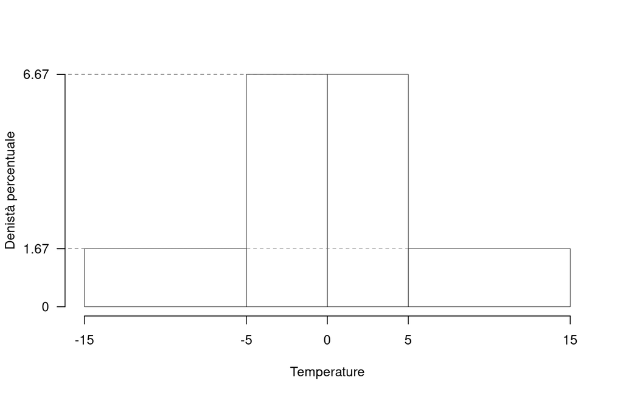

| $[\text{x}_j,$ | $\text{x}_{j+1})$ | $h_j$ |
| --- | --- | --- |
| -15 | -5 | 1.667 |
| -5 | 0 | 6.667 |
| 0 | 5 | 6.667 |
| 5 | 15 | 1.667 |

1.a **(Punti 14)** Calcolare il valore approssimato del 25-esimo percentile.

Per individuare il 25-esimo percentile dobbiamo:
$$b_j=x_{j+1}-x_{j}$$
le frequenze relative,
$$f_j=h_j\cdot b_j,$$
le cumulate
$$F_j=f_1+...+f_j$$
ricostruire la tabella

| $[\text{x}_j,$ | $\text{x}_{j+1})$ | $h_j$ | $b_j$ | $f_j$ | $F_j$ |
| --- | --- | --- | --- | --- | --- |
| -15 | -5 | 1.667 | 10 | 0.1667 | 0.1667 |
| -5 | 0 | 6.667 | 5 | 0.3333 | 0.5000 |
| 0 | 5 | 6.667 | 5 | 0.3333 | 0.8333 |
| 5 | 15 | 1.667 | 10 | 0.1667 | 1.0000 |
|  |  |  | 30 | 1.0000 |  |

$$\begin{eqnarray*}
p &=& 0.25 , \text{essendo }F_{ 2 }= 0.5 >
0.25 \Rightarrow j_{ 0.25 }= 2 \\
x_{ 0.25 } &=& x_{\text{inf}; 2 } + \frac{ { 0.25 } - F_{ 1 }}
{f_{ 2 }} \cdot b_{ 2 } \\
&=& -5 + \frac {{ 0.25 } - 0.1667 } { 0.3333 }
\cdot 5 \\
&=& -3.75
\end{eqnarray*}$$

1.b **(Punti 3)** Analizzando l’istogramma, individuare il valore della media aritmetica e della mediana.

L’istogramma è perfettamente simmetrico
$$\bar x\approx x_{0.5}\approx 0$$

1.c **(Punti 2)** Qual è la percentuale di dati compresa tra il 25-esimo e il 75-esimo percentile?

Per definizione
$$\begin{eqnarray*}
\%(X\le x_{0.25})&=&25\%\\
\%(X\le x_{0.75})&=&75\%, \qquad\text{e quindi}\\
\%(x_{0.25}< X\le x_{0.75})&=&50\%
\end{eqnarray*}$$

### Esercizio 2

Il numero di automobili in fila al semaforo $A$ in orario di punta è distribuito come una Poisson di parametro $\lambda_A=2.2$ ($X_A\sim \text{Pois}(2.2)$). Mentre il numero di automobili in fila al semaforo $B$ in orario di punta è distribuito come una Poisson di parametro $\lambda_B=1.5$ ($X_B\sim \text{Pois}(1.5)$). $X_A$ e $X_B$ indipendenti.

2.a **(Punti 14)** Calcolare la probabilità che in almeno uno dei due semafori ci siano 2 o più automobili in coda (suggerimento: *almeno uno* si rappresenta con l’unione).

Diretta
$$\begin{eqnarray*}
P( X_A \geq 2 ) &=& 1-P( X_A < 2 )
\\ &=& 1-\left( \frac{ 2.2 ^{ 0 }}{ 0 !}e^{- 2.2
}+\frac{ 2.2 ^{ 1 }}{ 1 !}e^{- 2.2 }
\right)\\ &=& 1-( 0.1108+0.2438
)\\ &=& 1- 0.3546
\\ &=& 0.6454
\end{eqnarray*}$$
$$\begin{eqnarray*}
P( X_B \geq 2 ) &=& 1-P( X_B < 2 )
\\ &=& 1-\left( \frac{ 1.5 ^{ 0 }}{ 0 !}e^{- 1.5
}+\frac{ 1.5 ^{ 1 }}{ 1 !}e^{- 1.5 }
\right)\\ &=& 1-( 0.2231+0.3347
)\\ &=& 1- 0.5578
\\ &=& 0.4422
\end{eqnarray*}$$
$$\begin{eqnarray*}
A =\{X_A\ge 2\} && B =\{X_B\ge 2\}\\
P(A\cup B) &=& P(A)+P(B)-P(A\cap B)\\
&=& 0.6454+0.4422-0.2854\\
&=& 0.8022
\end{eqnarray*}$$
Indiretta
$$\begin{eqnarray*}
\overline{\text{almeno uno}} &=& \text{nessuno}\\
\overline{A\cup B} &=& \bar A\cap \bar B\\
P(\overline{A\cup B}) &=& P(\bar A)P(\bar B)\\
P(A\cup B) &=& 1- P(X_A<2)(X_B<2)\\
&=& 1-(1-0.6454 )\times(1-0.4422)\\
&=& 0.8022
\end{eqnarray*}$$

2.b **(Punti 3)** Per andare al lavoro Michele prende la strada che lo porta al semaforo $A$, ($X_A\sim \text{Pois}(2.2)$) se la tangenziale è libera, altrimenti prende la strada che lo porta al semaforo $B$ ($X_B\sim \text{Pois}(1.5)$). La probabilità di trovare la tangenziale sia libera è pari a $P(\text{Libera})=0.65$. Qual è la probabilità che Michele incontri più di due auto in fila?

$$\begin{eqnarray*}
E &=& \{X\ge 2\}\\
P(E) &=&
P(\text{Libera})P(E|\text{Libera})+P\left(\overline{\text{Libera}}\right)P\left(E|\overline{\text{Libera}}\right)\\
&=& 0.65\times0.6454+(1-0.65)\times 0.4422\\
&=& 0.5743
\end{eqnarray*}$$

2.c **(Punti 2)** Sia $Z\sim N(0,1)$ e $Y\sim \chi^2_2$, $Z$ e $Y$ indipendenti. Come si distribuisce
$$\frac{Z}{\sqrt{Y/2}} ~~~?$$

2.d **(Punti 2)** Se $P(A)=0.3$, $P(B|A)=0.6$, e $P(B|\bar A)=0.4$, quanto valgono $P(B)$ e $P(A|B)$?

$$\begin{eqnarray*}
P(B) &=& P(A)P(B|A)+P(\bar A)P(B|\bar A)\\
&=& 0.3\times0.6+0.7\times 0.4\\
&=& 0.46\\
P(A|B) &=& \frac {P(A)P(B|A)}{P(B)}\\
&=& \frac {0.18}{0.46}\\
&=& 0.3913
\end{eqnarray*}$$

### Esercizio 3

3.a **(Punti 14)** Un’urna 3 premi da $\mbox{0}$ euro, un premio da $\mbox{1}$ euro. Si estrae 100 volte con reintroduzione.

Qual è la probabilità che la la vincita totale sia maggiore di 30?

**Teorema del Limite Centrale (somma di Bernoulli)**

Siano $X_1$,…,$X_n$, $n=100$ VC IID, tc $X_i\sim\text{Ber}(\pi=0.25)$$,\forall i$, posto:
$$S_n = X_1 + ... + X_n$$
allora:
$$\begin{eqnarray*}
S_n & \mathop{\sim}\limits_{a}& N(n\pi,n\pi(1-\pi)) \\
&\sim & N(100\cdot0.25,100\cdot0.25\cdot(1-0.25)) \\
&\sim & N(25,18.75)
\end{eqnarray*}$$
$$\begin{eqnarray*}
P( S_n > 30 )
&=& P\left( \frac { S_n - n\pi }{ \sqrt{n\pi(1-\pi)}
} > \frac { 30 - 25 }{\sqrt{ 18.75 }} \right) \\
&=& P\left( Z > 1.15 \right)
\\ &=& 1-P(Z< 1.15 )\\
&=& 1-\Phi( 1.15 ) \\ &=& 0.1251
\end{eqnarray*}$$

### Esercizio 4

4.a **(Punti 3)** Sia $\hat \lambda$ lo stimatore di massima verosimiglianza di $\lambda$ del modello Poisson.
$$\begin{eqnarray*}
\hat\lambda &=& \frac 1n\sum_{i=1}^nx_i\\
\end{eqnarray*}$$
Dimostrare le consistenza di $\hat\lambda$ in almeno tre passaggi.

4.b **(Punti 3)** Siano $h$ uno stimatore per $\theta$, cosa significa dire che $h$ è asintoticamente corretto?

4.c **(Punti 3)** Definire la probabilità di significatività.

4.d **(Punti 3)** Se in un test statistico $0.01 < p_\text{value} <0.05$ cosa possiamo concludere?

### Esercizio 5

5.a **(Punti 3)** In uno studio sulle spese mensili dei dipendenti di un’azienda, è stato selezionato un campione di 10 individui. I dati campionari hanno mostrato una media di spese mensili pari a $\hat\mu = 1200€$ con una deviazione standard osservata pari a $\hat\sigma = 300€$. Costruire un intervallo di confidenza al 95% per la media delle spese mensili $\mu$.

$1-\alpha =0.95$ e quindi $\alpha=0.05\rightarrow \alpha/2=0.025$

$$S =\sqrt{\frac {n}{n-1}}\cdot\hat\sigma =
\sqrt{\frac { 10 }{ 9 }}\cdot 300 = 316.2278$$
$$\begin{eqnarray*}
Idc: & & \hat\mu \pm t_{n-1;\alpha/2} \times
\frac{S}{\sqrt{n}} \\
& & 1200 \pm 2.262 \times \frac{ 316.2278 }{\sqrt{ 10 }}
\\
& & 1200 \pm 2.262 \times 100 \\
& & [ 973.8 , 1426 ]
\end{eqnarray*}$$

5.b **(Punti 11)** L’azienda afferma che la media delle spese mensili dei dipendenti è pari a $1100€$. Effettuare un test di ipotesi per verificare se la media delle spese mensili sia superiore a $1100€$.

**Test $t$ per una media, varianza incognita**

$\fbox{A}$ FORMULAZIONE DELLE IPOTESI

$$\begin{cases}
H_0: \mu = \mu_0=1100€ \\
H_1: \mu > \mu_0=1100€
\end{cases}$$

$$\begin{eqnarray*}
S &=& \sqrt{\frac{n} {n-1}}\ \widehat{\sigma}
= \sqrt{\frac{ 10 } { 10 -1}} \times 300 = 316.2
\end{eqnarray*}$$
$$\begin{eqnarray*}
\frac{\hat\mu - \mu_{0}} {S/\,\sqrt{n}}&\sim&t_{n-1}\\
t_{\text{obs}}
&=& \frac{ ( 1200 - 1100 )} { 316.2 /\sqrt{ 10 }}
= 1 \, .
\end{eqnarray*}$$

$\fbox{C}$ CONCLUSIONE

Consideriamo $\alpha=0.1, 0.05, 0.01, 0.001$

I valori critici sono

$t_{10-1;0.1}=1.383$; $t_{10-1;0.05}=1.8331$; $t_{10-1;0.01}=2.8214$; $t_{10-1;0.001}=4.2968$

Siccome $t_\text{obs}=1<t_{10-1;0.1}=1.383$, quindi **non** rifiuto $H_0$ a **nessun** livello di significatività,

$p_\text{value}>0.1$, *non significativo*

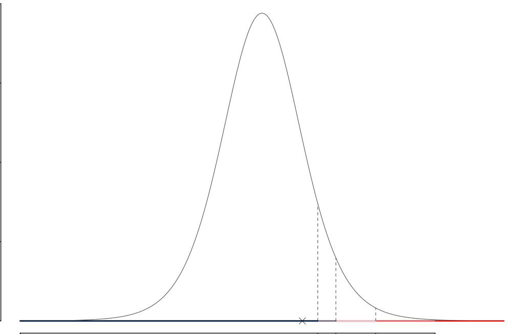

Il $p_{\text{value}}$ è

$$p_{\text{value}} =
P(T_{10-1}>1)=0.171718$$

Attenzione il calcolo del $p_\text{value}$ con la $T$ è puramente illustrativo e non può essere riprodotto senza una calcolatrice statistica adeguata.
$$0.1 < p_\text{value}= 0.171718 \leq 1$$

### Esercizio 6

Sono stati analizzati 5 comuni della provincia di Bologna e su ogni comune è stato rilevato il PIL pro capite del comune $X$, espresso in decine di migliaia di euro e un valore di percezione di qualità della vita $Y$ (espresso su opportuna scala).

Qui di seguito i dati

|  | A | B | C | D | E |
| --- | --- | --- | --- | --- | --- |
| $x_i$ | 0.4 | 1.0 | 1.3 | 2.7 | 3.1 |
| $y_i$ | 3.2 | 6.8 | 5.0 | 6.9 | 6.3 |

6.a **(Punti 14)** Calcolare il residuo del comune B nel modello di regressione dove $Y$ viene spiegata da $X$.

| $i$ | $x_i$ | $y_i$ | $x_i^2$ | $y_i^2$ | $x_i\cdot y_i$ |
| --- | --- | --- | --- | --- | --- |
| 1 | 0.4 | 3.20 | 0.16 | 10.24 | 1.28 |
| 2 | 1.0 | 6.80 | 1.00 | 46.24 | 6.80 |
| 3 | 1.3 | 5.00 | 1.69 | 25.00 | 6.50 |
| 4 | 2.7 | 6.90 | 7.29 | 47.61 | 18.63 |
| 5 | 3.1 | 6.30 | 9.61 | 39.69 | 19.53 |
| Totale | 8.5 | 28.20 | 19.75 | 168.78 | 52.74 |
| Totale/n | 1.7 | 5.64 | 3.95 | 33.76 | 10.55 |

$$\begin{eqnarray*}
\bar x &=&\frac 1 n\sum_{i=1}^n x_i = \frac {1}{ 5
} 8.5 = 1.7 \\
\bar y &=&\frac 1 n\sum_{i=1}^n y_i = \frac {1}{ 5
} 28.2 = 5.64 \\
\hat\sigma_X^2&=&\frac 1 n\sum_{i=1}^n x_i^2-\bar
x^2=\frac {1}{ 5 } 19.75 - 1.7 ^2= 1.06 \\
\hat\sigma_Y^2&=&\frac 1 n\sum_{i=1}^n y_i^2-\bar
y^2=\frac {1}{ 5 } 168.8 - 5.64 ^2= 1.946 \\
\text{cov}(X,Y)&=&\frac 1 n\sum_{i=1}^n x_i~y_i-\bar
x\bar y=\frac {1}{ 5 } 52.74 - 1.7 \cdot 5.64 = 0.96 \\
\hat\beta_1 &=&
\frac{\text{cov}(X,Y)}{\hat\sigma_X^2} \\
&=& \frac{ 0.96 }{ 1.06 } = 0.9057 \\
\hat\beta_0 &=& \bar y - \hat\beta_1 \bar x\\
&=& 5.64 - 0.9057 \times 1.7 = 4.1
\end{eqnarray*}$$
$$\begin{eqnarray*}
\hat y_i &=&\hat\beta_0+\hat\beta_1 x_i=\\
&=& 4.1 + 0.9057 \times 1 = 5.006 \\
\hat \varepsilon_i &=& y_i-\hat y_i\\
&=& 6.8 - 5.006 = 1.794
\end{eqnarray*}$$

6.b **(Punti 3)** Scrivere la scomposizione della varianza del modello di regressione e calcolare la Total Sum of Squares (TSS), la Explained Sum of Squares (ESS) e la Residual Sum of Squares (RSS) dei dati analizzati sopra.

$$\begin{eqnarray*}
TSS &=& n\hat\sigma^2_Y\\
&=& 5 \times 1.946 \\
&=& 9.732 \\
ESS &=& R^2\cdot TSS\\
&=& 0.4467 \cdot 9.732 \\
&=& 4.347 \\
RSS &=& (1-R^2)\cdot TSS\\
&=& (1- 0.4467 )\cdot 9.732 \\
&=& 5.385 \\
TSS &=& ESS+RSS \\ 9.732 &=& 4.347 + 5.385
\end{eqnarray*}$$

6.c **(Punti 3)** Interpretare il parametro di regressione $\hat\beta_1$.

6.d **(Punti 2)** Descrivere la differenza tra punti di leva e punti influenti.

6.e **(Punti 2)** Gli stimatori $\hat\beta_0$ e $\hat\beta_1$ dei minimi quadrati per $\beta_0$ e $\beta_1$ sono corretti?